# Statistics for Bioengineering - Week 5

Bill Cresko

# Week 5: Linear Models

## Week 5 Topics

- Ordinary Linear Models (OLMs)
- Simple linear regression
- Loss function - sum of squared error (SSE and MSE)
- Residual analysis to test assumptions
- The eugenics origin of linear models

**Note**

**Readings:** Chapters 21-24

**HW2 Due this week - on Thursday**

## Packages for This Week

- Install/Load
- Interpretation

```r
# Install new packages (run once)
install.packages(c("ggfortify", "lmodel2"))

# Load packages
library(tidyverse)    # Data manipulation & visualization
library(ggfortify)    # ggplot2 extensions for model diagnostics
library(lmodel2)      # Model II regression (when X and Y both have error)
library(broom)
library(knitr)
```

- **tidyverse**: Core data manipulation and visualization (includes ggplot2, dplyr, readr, etc.).
- **ggfortify**: Extends ggplot2 to produce diagnostic plots from model objects via `autoplot()`.
- **lmodel2**: Provides Model II regression methods (MA, SMA, RMA) for when both X and Y have measurement error.
- **broom**: Tidies model output into data frames with `tidy()` (coefficients) and `glance()` (model-level statistics).
- **knitr**: Provides `kable()` for rendering tables in presentations and reports.

# Linear Models

## Classes of Linear Models

| Abbreviation | Name | Description |
| --- | --- | --- |
| **GLM** | General Linear Model | Continuous variables |
| **GLMM** | General Linear Mixed Model | Mixed continuous/categorical |
| **Generalized LM** | Generalized Linear Model | Non-normal response |
| **GAM** | Generalized Additive Model | Non-linear relationships |

## What is a Ordinary Linear Model?

An ordinary linear model describes the relationship between a continuous response variable $y$ and one or more predictor variables $x$. In its simplest form with one predictor, the model is:

- Equation
- LaTeX
- Interpretation

$$y_i = \beta_0 + \beta_1 x_i + \epsilon_i$$

```
y_i = \beta_0 + \beta_1 x_i + \epsilon_i
```

- This is the fundamental equation of simple linear regression: each observation $y_i$ is modeled as a linear function of $x_i$ plus random error.
- $\beta_0$ (intercept) is the expected value of Y when X equals zero; $\beta_1$ (slope) is the expected change in Y per unit increase in X.
- $\epsilon_i$ captures everything the model does not explain – measurement error, unmeasured variables, and natural variability.

where:

- $\beta_0$: intercept — the expected value of $y$ when $x = 0$
- $\beta_1$: slope — the expected change in $y$ for a one-unit increase in $x$
- $\epsilon_i$: error/residual — the deviation of observation $i$ from the fitted line

The goal of fitting a linear model is to estimate $\beta_0$ and $\beta_1$ from our data.

## Simple Linear Regression Example

- Output
- Code
- Interpretation

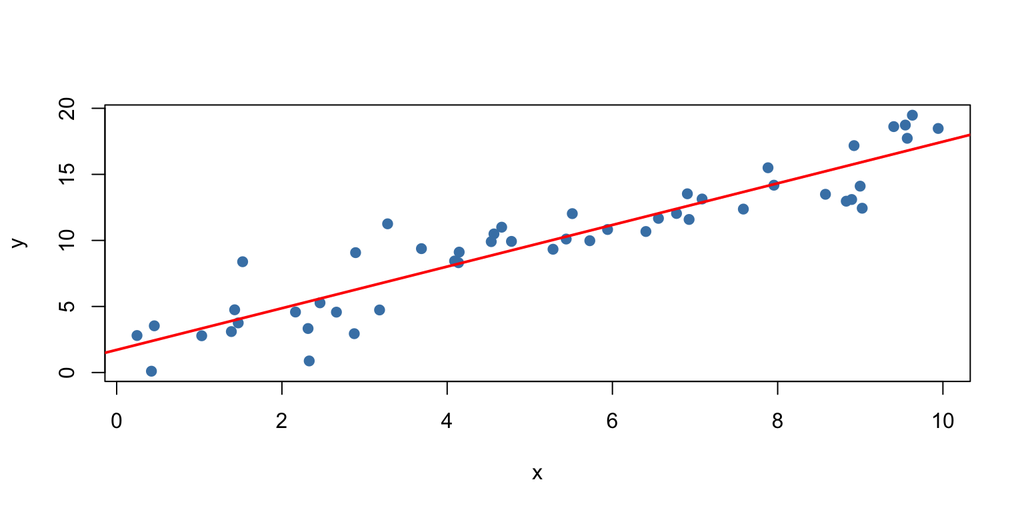

```r
# This part of the code creates two variables, one with random error that is normally distributed
set.seed(123)
x <- runif(50, 0, 10)
y <- 2 + 1.5*x + rnorm(50, 0, 2)

# This part of the code is fitting the model, plotting the points and the best fit line
my_lm <- lm(y ~ x)
plot(x, y, pch = 19, col = "steelblue")
abline(my_lm, col = "red", lwd = 2)
```

- This example creates simulated data with a known linear relationship ($y = 2 + 1.5x + \text{noise}$) to demonstrate how `lm()` fits a regression line.
- The `set.seed(123)` ensures reproducibility – you will get the same “random” data each time.
- The scatter shows points around the true line, and `abline()` overlays the OLS-estimated best fit in red.

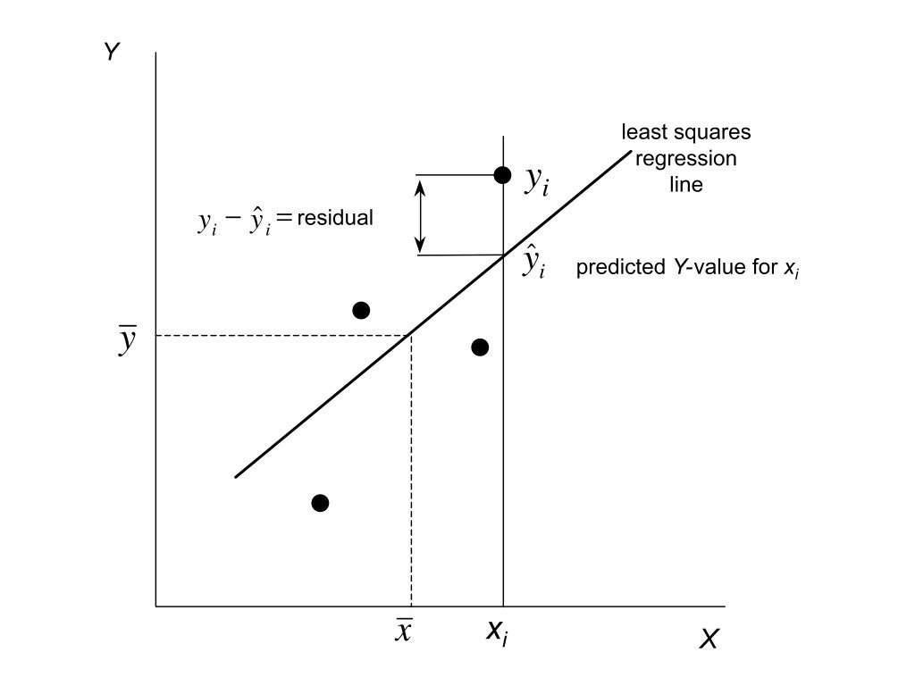

## (SVG)

[figure not shown]

## DRAFT: Residuals and Least Squares

- Output
- Code
- Interpretation

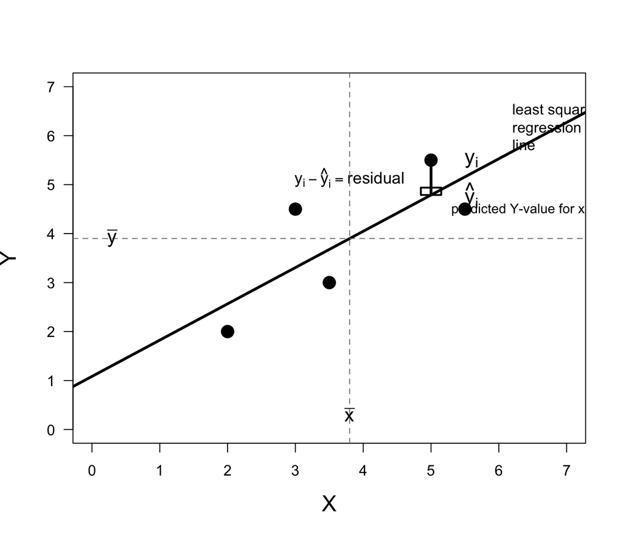

```r
set.seed(42)
x <- c(2, 3, 3.5, 5, 5.5)
y <- c(2, 4.5, 3, 5.5, 4.5)
fit <- lm(y ~ x)
pred <- predict(fit)

plot(x, y, pch = 16, cex = 2, xlim = c(0, 7), ylim = c(0, 7),
     xlab = "X", ylab = "Y", las = 1)
abline(fit, lwd = 3)

# Show residual for a point
i <- 4
segments(x[i], pred[i], x[i], y[i], lwd = 3, col = "black")
text(x[i] + 0.6, y[i], bquote(y[i]), cex = 1.4)
text(x[i] + 0.6, pred[i], bquote(hat(y)[i]), cex = 1.4)

# Show means
abline(h = mean(y), lty = 2, col = "gray50")
abline(v = mean(x), lty = 2, col = "gray50")
```

- The vertical distance between each observed point ($y_i$) and the regression line ($\hat{y}_i$) is the **residual** for that observation.
- The least squares regression line always passes through the point ($\bar{x}$, $\bar{y}$) – the means of X and Y.
- OLS finds the line that minimizes the sum of all squared residuals, giving the “best fit” in the least-squares sense.

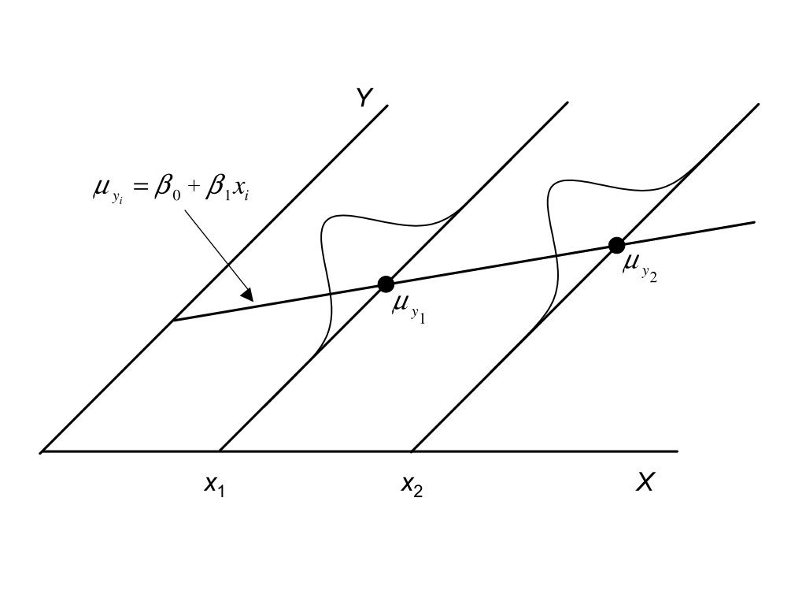

## (SVG)

[figure not shown]

## DRAFT: Regression Conditional Distributions

- Output
- Code
- Interpretation

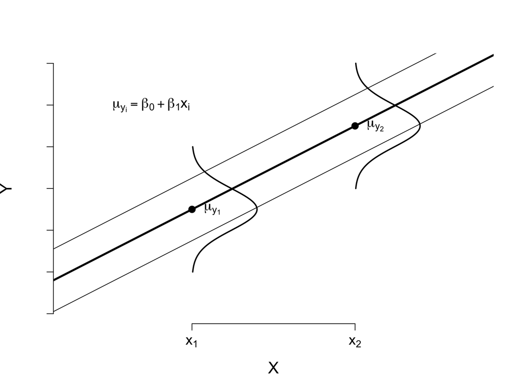

```r
plot(NULL, xlim = c(0, 10), ylim = c(0, 12),
     xlab = "X", ylab = "Y", las = 1, cex.lab = 1.5, axes = FALSE)
axis(1, at = c(3, 7), labels = c(expression(x[1]), expression(x[2])))
axis(2, labels = FALSE)

abline(a = 2, b = 1, lwd = 3)  # Regression line

# Normal distributions at each x value
for (xi in c(3, 7)) {
  mu_y <- 2 + xi
  y_seq <- seq(mu_y - 3, mu_y + 3, length.out = 100)
  dens <- dnorm(y_seq, mean = mu_y, sd = 1)
  lines(xi + dens * 4, y_seq, lwd = 2)
  points(xi, mu_y, pch = 16, cex = 1.5)
}
```

- At each value of X, the response Y follows a normal distribution centered on the regression line ($\mu_{y_i} = \beta_0 + \beta_1 x_i$).
- The **equal variance** assumption (homoscedasticity) means these conditional distributions all have the same spread ($\sigma^2$), regardless of the X value.
- The **normality** assumption applies to these conditional distributions (or equivalently, to the residuals), not to the marginal distribution of Y.

## Hypothesis Tests in Regression

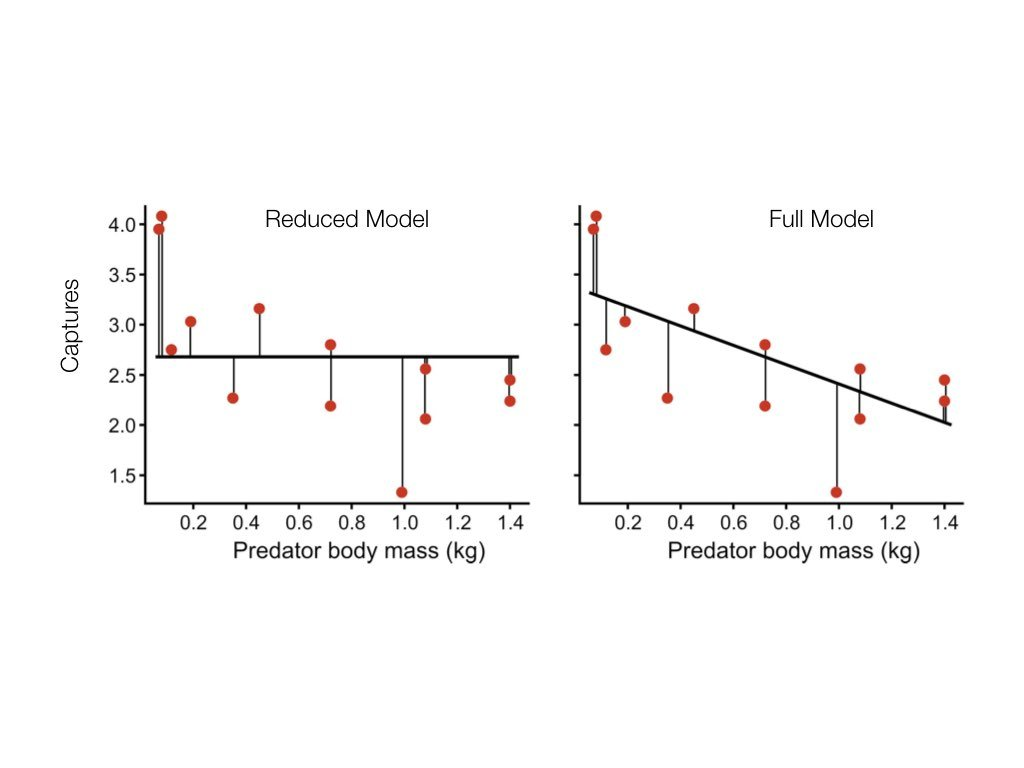

## Hypothesis Tests in Regression (SVG)

[figure not shown]

## DRAFT: Reduced vs Full Model Residuals

- Output
- Code
- Interpretation

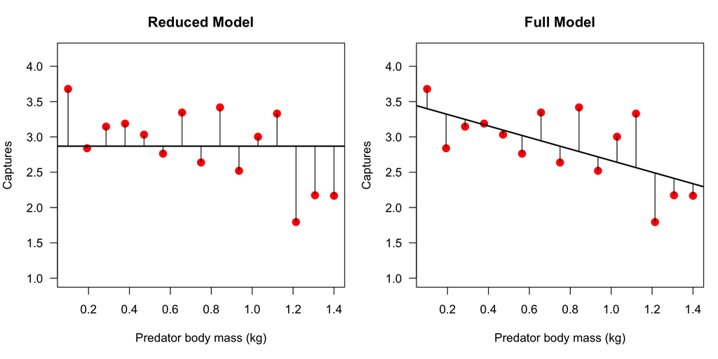

```r
set.seed(42)
x <- seq(0.1, 1.4, length.out = 15)
y <- 3.2 - 0.7 * x + rnorm(15, 0, 0.4)

par(mfrow = c(1, 2), mar = c(5, 4, 3, 1))

# Reduced model (mean only)
plot(x, y, pch = 16, col = "red", cex = 1.5,
     xlab = "Predator body mass (kg)", ylab = "Captures",
     main = "Reduced Model", ylim = c(1, 4.2), las = 1)
abline(h = mean(y), lwd = 2)
segments(x, mean(y), x, y, lwd = 1)

# Full model (regression)
plot(x, y, pch = 16, col = "red", cex = 1.5,
     xlab = "Predator body mass (kg)", ylab = "Captures",
     main = "Full Model", ylim = c(1, 4.2), las = 1)
fit <- lm(y ~ x)
abline(fit, lwd = 2)
segments(x, predict(fit), x, y, lwd = 1)
```

- The **reduced model** ($H_0$: $\beta_1 = 0$) uses only the overall mean to predict Y – the residuals (vertical lines) are the deviations from that horizontal line.
- The **full model** adds the predictor X, allowing the line to tilt. The residuals from the regression line are visibly smaller.
- The F-test compares these two sets of residuals: if the full model’s residuals are substantially smaller, the predictor is significant.

## Hypothesis Tests in Regression

- Equation
- LaTeX
- Interpretation

$$H_0: \beta_1 = 0 \quad \text{(no relationship)}$$
$$H_A: \beta_1 \neq 0 \quad \text{(relationship exists)}$$

```
H_0: \beta_1 = 0 \quad \text{(no relationship)}
H_A: \beta_1 \neq 0 \quad \text{(relationship exists)}
```

- The null hypothesis states that the slope is zero – meaning X has no linear relationship with Y.
- The alternative hypothesis states the slope is nonzero – meaning X does predict Y.
- This is tested by comparing the reduced model (intercept only, $H_0$) to the full model (intercept + slope, $H_A$) via the F-test.

Compares:

- Reduced model: $y_i = \beta_0 + \epsilon_i$
- Full model: $y_i = \beta_0 + \beta_1 x_i + \epsilon_i$

## Sum of Squares

| Term | Description |
| --- | --- |
| $SS_{Total}$ | Total variability in data |
| $SS_{Model}$ | Variability explained by model |
| $SS_{Error}$ | Unexplained variability |

- Equation
- LaTeX
- Interpretation

$$SS_{Total} = SS_{Model} + SS_{Error}$$

```
SS_{Total} = SS_{Model} + SS_{Error}
```

- This fundamental identity shows that total variability in the data can be decomposed into two parts: what the model explains ($SS_{Model}$) and what remains unexplained ($SS_{Error}$).
- A good model will have a large $SS_{Model}$ relative to $SS_{Error}$, meaning most of the variability is accounted for by the predictor.
- This decomposition is the basis for the F-test and for computing $R^2$.

## The Loss Function: Minimizing Error

Linear regression finds the line of best fit by minimizing the **sum of squared errors (SSE)**. For each observation, the residual is the difference between the observed and predicted value:

- Equation
- LaTeX
- Interpretation

$$e_i = y_i - \hat{y}_i = y_i - (\hat{\beta}_0 + \hat{\beta}_1 x_i)$$

```
e_i = y_i - \hat{y}_i = y_i - (\hat{\beta}_0 + \hat{\beta}_1 x_i)
```

- The residual $e_i$ is the vertical distance between the observed value $y_i$ and the predicted value $\hat{y}_i$ on the regression line.
- Positive residuals indicate the observation is above the line; negative residuals indicate it is below.
- Examining residual patterns is the primary method for checking whether regression assumptions are met.

The SSE is the total squared deviation of all observations from the fitted line:

- Equation
- LaTeX
- Interpretation

$$SSE = \sum_{i=1}^{n} e_i^2 = \sum_{i=1}^{n} (y_i - \hat{y}_i)^2$$

```
SSE = \sum_{i=1}^{n} e_i^2 = \sum_{i=1}^{n} (y_i - \hat{y}_i)^2
```

- SSE is the total squared deviation of all observations from the fitted line – the quantity that OLS minimizes.
- Each residual is squared so that positive and negative deviations do not cancel out.
- Comparing SSE between models (e.g., reduced vs. full) forms the basis of the F-test for regression significance.

The **mean squared error (MSE)** normalizes by degrees of freedom:

- Equation
- LaTeX
- Interpretation

$$MSE = \frac{SSE}{n - p}$$

```
MSE = \frac{SSE}{n - p}
```

- MSE normalizes the SSE by degrees of freedom, providing an unbiased estimate of the residual variance.
- For simple linear regression, $p = 2$ (one intercept + one slope), so MSE = SSE / ($n - 2$).
- MSE is the denominator of the F-statistic and is used to calculate standard errors of the regression coefficients.

where $p$ is the number of parameters estimated (2 for simple linear regression: intercept and slope). Ordinary Least Squares (OLS) is the method that finds the values of $\hat{\beta}_0$ and $\hat{\beta}_1$ that minimize the SSE.

## Hypothesis Tests in Regression

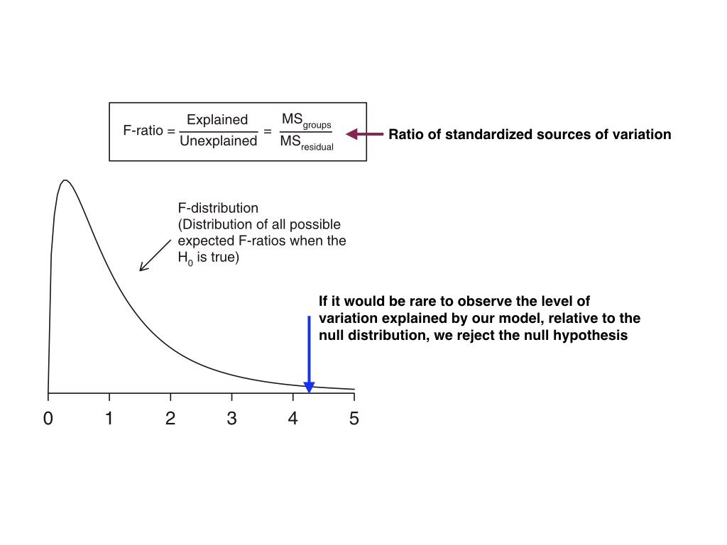

## Hypothesis Tests in Regression (SVG)

[figure not shown]

## DRAFT: F-Ratio and the F-Distribution

- Equation
- LaTeX
- Interpretation

$$\text{F-ratio} = \frac{\text{Explained}}{\text{Unexplained}} = \frac{MS_{groups}}{MS_{residual}}$$

```
\text{F-ratio} = \frac{\text{Explained}}{\text{Unexplained}} = \frac{MS_{groups}}{MS_{residual}}
```

- The F-ratio compares the variance explained by the model to the unexplained (residual) variance.
- An F-ratio near 1 means the model explains no more variance than expected by chance (consistent with $H_0$).
- A large F-ratio means the model explains substantially more variance than expected, providing evidence against $H_0$.

**Ratio of standardized sources of variation**

- Output
- Code
- Interpretation

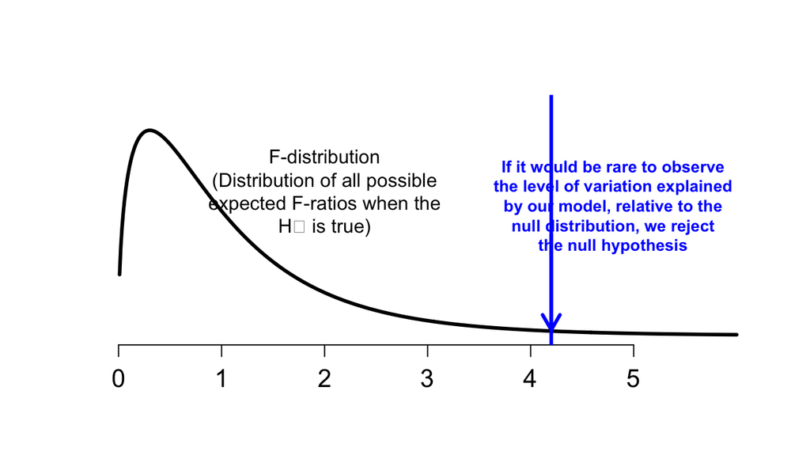

```r
x <- seq(0.01, 6, length.out = 500)
plot(x, df(x, df1 = 3, df2 = 20), type = "l", lwd = 3,
     xlab = "", ylab = "", axes = FALSE, ylim = c(0, 0.8))
axis(1, at = 0:5, cex.axis = 1.3)
abline(v = 4.2, col = "blue", lwd = 3)
arrows(4.2, 0.35, 4.2, 0.02, col = "blue", lwd = 3, length = 0.15)
```

- The plot shows the F-distribution under the null hypothesis (df1=3, df2=20).
- The blue arrow marks the observed F-statistic at 4.2. Because it falls far in the right tail, the probability of observing this value under $H_0$ is very small.
- If the observed F-ratio falls in this extreme region, we reject $H_0$ and conclude the model explains a significant amount of variance.

## R² as Measure of Fit (~ effect size)

- Equation
- LaTeX
- Interpretation

$$R^2 = \frac{SS_{Model}}{SS_{Total}} = 1 - \frac{SS_{Error}}{SS_{Total}}$$

```
R^2 = \frac{SS_{Model}}{SS_{Total}} = 1 - \frac{SS_{Error}}{SS_{Total}}
```

- $R^2$ represents the proportion of total variance in Y that is explained by the model (predictor X).
- It ranges from 0 (model explains nothing) to 1 (model explains all variance). For simple linear regression, $R^2 = r^2$ (the squared Pearson correlation).
- A high $R^2$ does not guarantee the model is correct – always check residual diagnostics alongside $R^2$.

$R^2$ is the proportion of variance in Y explained by X. It ranges from 0 (model explains none of the variance) to 1 (model explains all of the variance). For simple linear regression, $R^2$ equals the square of the Pearson correlation coefficient $r$.

**Note**

A high $R^2$ does not necessarily mean the model is appropriate — always check residual diagnostics!

## Components of an lm Object

When you fit a model with `lm()`, R stores many useful components in the returned object:

| Component | Description | Accessor Function |
| --- | --- | --- |
| `coefficients` | Estimated $\beta$ values | `coef()` |
| `residuals` | Observed minus fitted values ($y_i - \hat{y}_i$) | `residuals()` or `resid()` |
| `fitted.values` | Predicted values ($\hat{y}_i$) | `fitted()` |
| `rank` | Rank of the design matrix | — |
| `df.residual` | Residual degrees of freedom | `df.residual()` |
| `call` | The original function call | — |
| `terms` | The model formula terms | — |
| `model` | The data frame used for fitting | `model.frame()` |
| `qr` | QR decomposition of design matrix | — |
| `effects` | Orthogonal effects | — |

## Extracting Model Information

- Output
- Code
- Interpretation

```
 [1] "coefficients"  "residuals"     "effects"       "rank"
 [5] "fitted.values" "assign"        "qr"            "df.residual"
 [9] "xlevels"       "call"          "terms"         "model"
```

```
(Intercept)           x
   1.715295    1.576349
```

```
          1           2           3           4           5           6
-3.30824354  1.35841703  0.27920218 -2.66574273  2.07429862  1.10285197
          7           8           9          10          11          12
-0.70864040  1.39360442  1.61995770  1.57924715  0.93145398  1.04642498
         13          14          15          16          17          18
-0.35643588 -0.76441934 -0.55481847 -1.79171521 -0.31901447 -2.27819928
         19          20          21          22          23          24
 4.37225341  1.97187616 -2.64066543 -1.05001219 -1.13762534  1.08552139
         25          26          27          28          29          30
-0.38265703  0.25038707 -0.18777664 -0.25465653  2.80113964 -0.27915624
         31          32          33          34          35          36
 2.58238800 -3.50169579  0.92658688 -0.07491690  0.69779627  0.67919231
         37          38          39          40          41          42
-1.29901717 -0.54693448 -1.99537312 -2.03572083  0.78273642  0.86462332
         43          44          45          46          47          48
 0.07483981  1.84763083  4.26848487 -0.80333385 -4.51155136  1.94042516
         49          50
-1.33676335 -1.74625403
```

```r
# View all components
names(my_lm)

# Access individual components
my_lm$coefficients
my_lm$residuals
```

- `names()` reveals all the components stored inside an `lm` object – these are the building blocks for diagnostics and interpretation.
- `coefficients` gives the estimated intercept ($\hat{\beta}_0$) and slope ($\hat{\beta}_1$).
- `residuals` gives the difference between observed and predicted values ($y_i - \hat{y}_i$) for each observation, which are central to assumption checking.

## Extracting Model Information

- Output
- Code
- Interpretation

```
                2.5 %   97.5 %
(Intercept) 0.6210192 2.809570
x           1.3927850 1.759913
```

```r
# Confidence intervals
confint(my_lm)
```

- `confint()` returns the 95% confidence intervals for the intercept and slope.
- If the confidence interval for $\beta_1$ does not include 0, we have evidence that the predictor has a significant linear relationship with the response.
- Wider intervals indicate greater uncertainty in the parameter estimates, often due to small sample size or high variability.

## Extracting Model Information

- Output
- Code
- Interpretation

```
        fit       lwr       upr
1  4.867992  4.073494  5.662491
2  9.597039  9.060991 10.133087
3 14.326086 13.584473 15.067699
```

```r
# Make predictions
predict(my_lm, data.frame(x = c(2, 5, 8)), interval = "confidence")
```

- `predict()` with `interval = "confidence"` returns the predicted mean response at each new x-value, along with lower and upper 95% confidence bounds.
- These confidence intervals represent uncertainty in the **mean** response, not individual observations (use `interval = "prediction"` for individual prediction intervals, which are wider).
- Predictions are most reliable within the range of the original data; extrapolation beyond the data range is risky.

# Subgroups in simple linear regression

## Simpson’s Paradox

A trend that appears in groups can disappear or reverse when groups are combined.

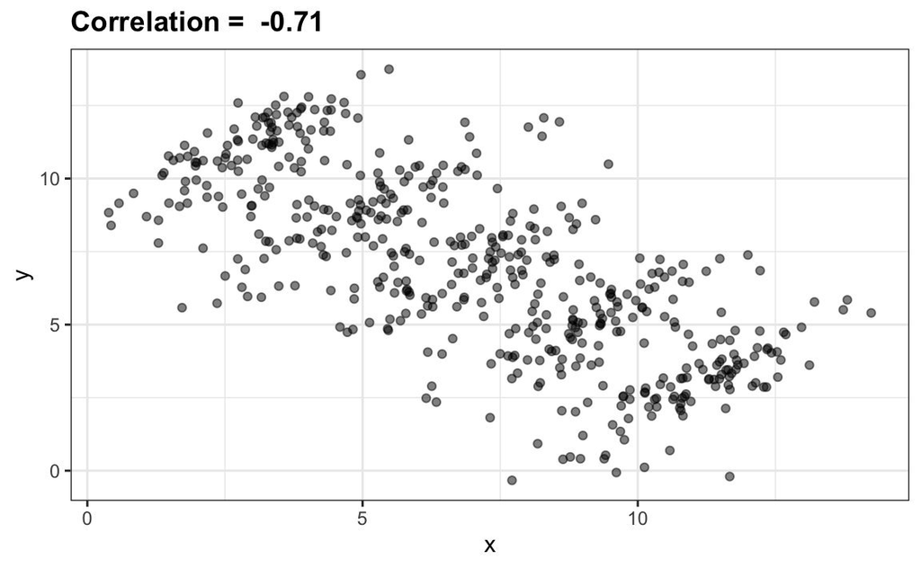

Source: Simpson’s Paradox illustration

## DRAFT: Simpson’s Paradox

- Output
- Code
- Interpretation

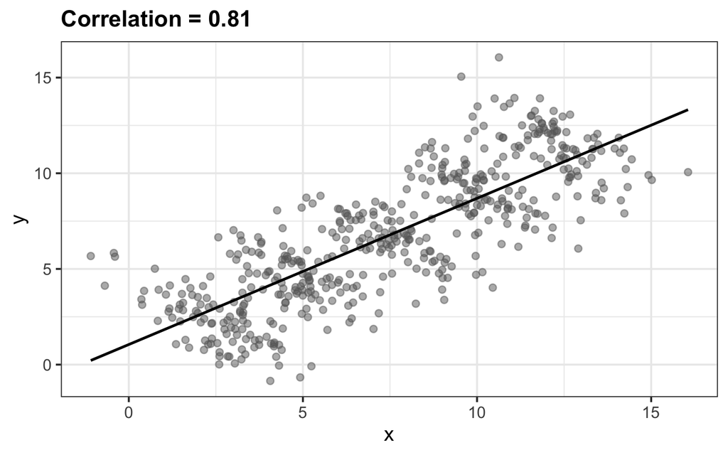

```r
library(ggplot2)
set.seed(42)
groups <- 5
n_per <- 100
z <- rep(1:groups, each = n_per)
x <- z * 2.5 + rnorm(groups * n_per, 0, 1.2)
y <- -0.7 * x + z * 4 + rnorm(groups * n_per, 0, 1)

df <- data.frame(x = x, y = y, z = factor(z))

ggplot(df, aes(x, y)) +
  geom_point(alpha = 0.5, color = "gray40") +
  geom_smooth(method = "lm", se = FALSE, color = "black", linewidth = 1) +
  labs(title = paste("Correlation =", round(cor(x, y), 2)),
       x = "x", y = "y") +
  theme_bw(base_size = 16)
```

- The overall correlation appears positive when all data are combined, ignoring group structure.
- This is a setup for Simpson’s Paradox: the aggregate trend may be misleading because it ignores a confounding variable (group membership z).
- The next slide reveals what happens when we color by group – the within-group trends may differ dramatically from the overall trend.

## Simpson’s Paradox Explained

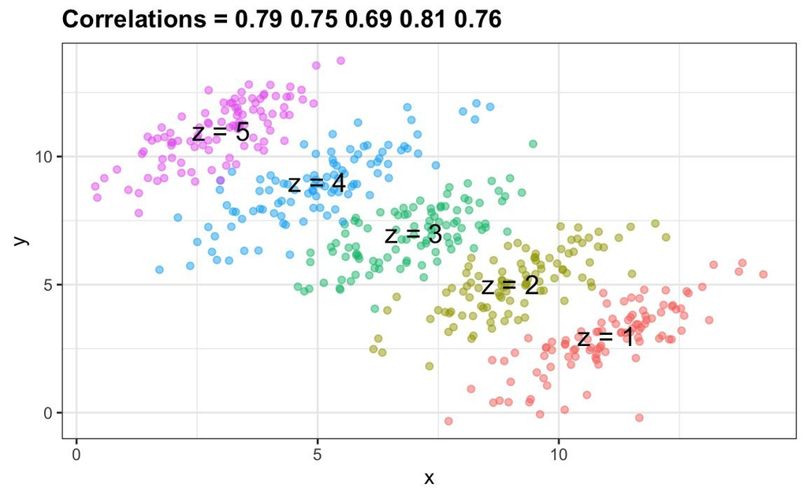

Source: Simpson’s Paradox illustration

## DRAFT: Simpson’s Paradox Explained

- Output
- Code
- Interpretation

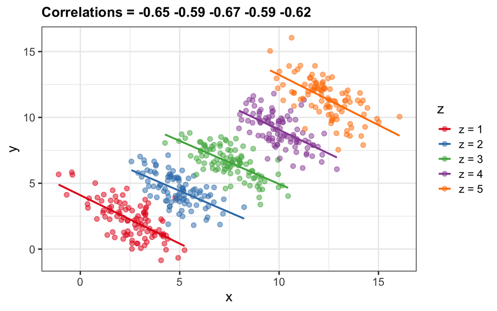

```r
library(ggplot2)
set.seed(42)
groups <- 5
n_per <- 100
z <- rep(1:groups, each = n_per)
x <- z * 2.5 + rnorm(groups * n_per, 0, 1.2)
y <- -0.7 * x + z * 4 + rnorm(groups * n_per, 0, 1)

df <- data.frame(x = x, y = y, z = factor(z))
cors <- sapply(split(df, df$z), function(d) round(cor(d$x, d$y), 2))

ggplot(df, aes(x, y, color = z)) +
  geom_point(alpha = 0.5) +
  geom_smooth(method = "lm", se = FALSE, linewidth = 1) +
  labs(title = paste("Correlations =", paste(cors, collapse = " ")),
       x = "x", y = "y") +
  scale_color_brewer(palette = "Set1", labels = paste("z =", 1:5))
```

- When colored by group (z), each subgroup shows a **negative** correlation between x and y, even though the overall trend appeared positive.
- This reversal occurs because the confounding variable z drives both x and y upward across groups, creating an artificial positive association.
- This is a classic example of why controlling for confounding variables is critical in regression analysis – ignoring group structure leads to the wrong conclusion.

## In-Class Demo: Simpson’s Paradox with Iris Data

- Output
- Code
- Interpretation

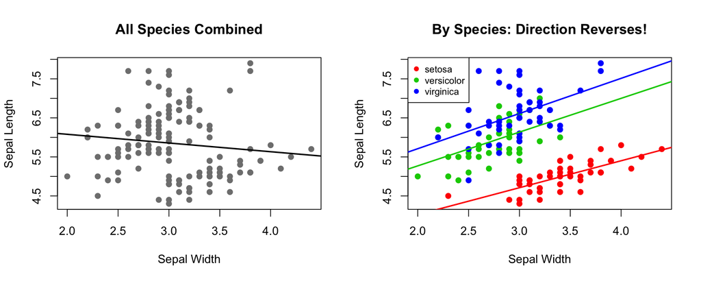

```r
par(mfrow = c(1, 2))

# Overall: negative correlation
plot(iris$Sepal.Width, iris$Sepal.Length, pch = 19, col = "gray50",
     xlab = "Sepal Width", ylab = "Sepal Length",
     main = "All Species Combined")
abline(lm(Sepal.Length ~ Sepal.Width, iris), col = "black", lwd = 2)
cat("Overall correlation:", round(cor(iris$Sepal.Width, iris$Sepal.Length), 3))

# By species: positive correlation within each!
colors <- c("red", "green3", "blue")
plot(iris$Sepal.Width, iris$Sepal.Length, pch = 19,
     col = colors[as.numeric(iris$Species)],
     xlab = "Sepal Width", ylab = "Sepal Length",
     main = "By Species: Direction Reverses!")
for(i in 1:3) {
  sp_data <- iris[iris$Species == levels(iris$Species)[i], ]
  abline(lm(Sepal.Length ~ Sepal.Width, sp_data), col = colors[i], lwd = 2)
}
legend("topleft", levels(iris$Species), col = colors, pch = 19, cex = 0.8)
```

- The left panel shows a negative overall correlation between sepal width and sepal length when all species are combined.
- The right panel reveals that within each species, the correlation is actually positive – the trend reverses when we account for species.
- This is a real-world example of Simpson’s Paradox: the confounding variable (species) drives both sepal dimensions and creates a spurious negative overall trend.

**Important**

The overall negative trend reverses to positive within each species — a classic confounding variable problem!

## R Exercise: Linear Regression

- Load the grip_strength.csv` dataset
- The data set has one reponse variable and two predictor variables:
  - response: grip_strength
  - predictor 1: bmp2_cream
  - predictor 2: exercise_hours
- Run appropriate correlation test
- Create scatterplots and check the fit
- Fit a linear model with `lm()`
- Interpret coefficients and R²

## The Loss Function: Minimizing Error

Linear regression finds the line of best fit by minimizing the **sum of squared errors (SSE)**. For each observation, the residual is the difference between the observed and predicted value:

- Equation
- LaTeX
- Interpretation

$$e_i = y_i - \hat{y}_i = y_i - (\hat{\beta}_0 + \hat{\beta}_1 x_i)$$

```
e_i = y_i - \hat{y}_i = y_i - (\hat{\beta}_0 + \hat{\beta}_1 x_i)
```

- The residual $e_i$ measures how far each observed value falls from the predicted value on the regression line.
- Positive residuals mean the observation is above the line; negative residuals mean it is below.
- Examining residuals is the foundation of regression diagnostics – patterns in the residuals reveal assumption violations.

The SSE is the total squared deviation of all observations from the fitted line:

- Equation
- LaTeX
- Interpretation

$$SSE = \sum_{i=1}^{n} e_i^2 = \sum_{i=1}^{n} (y_i - \hat{y}_i)^2$$

```
SSE = \sum_{i=1}^{n} e_i^2 = \sum_{i=1}^{n} (y_i - \hat{y}_i)^2
```

- SSE sums the squared residuals across all observations – squaring ensures positive and negative residuals do not cancel.
- This is the quantity that OLS minimizes: the best-fit line is the one that makes this sum as small as possible.
- Larger SSE indicates more unexplained variability; smaller SSE indicates a better-fitting model.

The **mean squared error (MSE)** normalizes by degrees of freedom:

- Equation
- LaTeX
- Interpretation

$$MSE = \frac{SSE}{n - p}$$

```
MSE = \frac{SSE}{n - p}
```

- MSE divides the SSE by the degrees of freedom ($n - p$), giving an unbiased estimate of the error variance $\sigma^2$.
- For simple linear regression, $p = 2$ (intercept and slope), so we divide by $n - 2$.
- Smaller MSE indicates the model fits the data more closely, with less unexplained variability per observation.

where $p$ is the number of parameters estimated (2 for simple linear regression: intercept and slope). Ordinary Least Squares (OLS) is the method that finds the values of $\hat{\beta}_0$ and $\hat{\beta}_1$ that minimize the SSE.

## The Grip Strength Dataset

- This dataset examines whether grip strength (in kg) in patients recovering from hand injury is predicted by two continuous variables:
  - the concentration of a BMP2 cream applied topically (mg/ml), and
  - hours of exercise per week. We have 200 patients.
- We will fit separate simple linear regressions for each predictor, then explore which model is more appropriate by examining residual diagnostics.

## Importing and Exploring the Data

- Output
- Code
- Interpretation

| patient_id | grip_strength_kg | bmp2_cream_mg_ml | exercise_hrs_week |
| --- | --- | --- | --- |
| PT001 | 43.7 | 3.75 | 12.8 |
| PT002 | 42.4 | 9.51 | 1.7 |
| PT003 | 43.4 | 7.32 | 3.2 |
| PT004 | 36.7 | 5.99 | 18.0 |
| PT005 | 37.9 | 1.56 | 12.1 |
| PT006 | 27.3 | 1.56 | 0.2 |
| PT007 | 29.8 | 0.58 | 2.0 |
| PT008 | 48.7 | 8.66 | 13.3 |

```r
library(tidyverse)
library(broom)
library(knitr)

grip <- read_csv("data/grip_strength_data.csv")

# Preview the data
head(grip, 8) |> kable(digits = 2)
```

- We load the grip strength dataset and preview the first 8 rows to verify the data imported correctly and understand its structure.
- The dataset contains measurements of grip strength (response), BMP2 cream concentration, and exercise hours (predictors) for each patient.
- Always inspect your data before modeling – check for unexpected values, missing data, or formatting issues.

## Summary Statistics of the Data

- Output
- Code
- Interpretation

```
 grip_strength_kg bmp2_cream_mg_ml exercise_hrs_week
 Min.   :21.70    Min.   :0.060    Min.   : 0.100
 1st Qu.:34.38    1st Qu.:2.288    1st Qu.: 5.225
 Median :38.95    Median :4.945    Median :10.850
 Mean   :38.83    Mean   :4.840    Mean   :10.086
 3rd Qu.:43.62    3rd Qu.:7.572    3rd Qu.:14.825
 Max.   :51.50    Max.   :9.870    Max.   :19.800
```

```r
summary(grip[, c("grip_strength_kg", "bmp2_cream_mg_ml", "exercise_hrs_week")])
```

- The summary statistics provide the min, quartiles, mean, and max for each variable, giving a quick overview of the data distribution.
- Check whether the ranges make sense (e.g., grip strength should be positive, exercise hours should be reasonable).
- Large differences between mean and median suggest skewness that might affect model assumptions.

## Grip Strength ~ BMP2 Cream

We hypothesize that BMP2 cream concentration is positively associated with grip strength. The model is:

- Equation
- LaTeX
- Interpretation

$$\text{grip_strength}_i = \beta_0 + \beta_1 \cdot \text{bmp2_cream}_i + \epsilon_i$$

```
\text{grip_strength}_i = \beta_0 + \beta_1 \cdot \text{bmp2_cream}_i + \epsilon_i
```

- This is the simple linear regression model predicting grip strength from BMP2 cream concentration.
- $\beta_0$ is the expected grip strength when no BMP2 cream is applied (concentration = 0).
- $\beta_1$ represents the expected change in grip strength (kg) for each 1 mg/ml increase in BMP2 cream concentration.

## Grip Strength ~ BMP2 Cream

The `summary()` output gives us the estimated coefficients, their standard errors, t-statistics, and p-values, plus the overall model $R^2$ and F-test.

- Output
- Code
- Interpretation

```
Call:
lm(formula = grip_strength_kg ~ bmp2_cream_mg_ml, data = grip)

Residuals:
    Min      1Q  Median      3Q     Max
-9.6358 -2.8946  0.3596  2.9765  9.6819

Coefficients:
                 Estimate Std. Error t value Pr(>|t|)
(Intercept)      30.89979    0.56202   54.98   <2e-16 ***
bmp2_cream_mg_ml  1.63861    0.09923   16.51   <2e-16 ***
---
Signif. codes:  0 '***' 0.001 '**' 0.01 '*' 0.05 '.' 0.1 ' ' 1

Residual standard error: 4.128 on 198 degrees of freedom
Multiple R-squared:  0.5794,    Adjusted R-squared:  0.5772
F-statistic: 272.7 on 1 and 198 DF,  p-value: < 2.2e-16
```

```r
lm_bmp2 <- lm(grip_strength_kg ~ bmp2_cream_mg_ml, data = grip)
summary(lm_bmp2)
```

- The `summary()` output shows the estimated intercept and slope, along with their standard errors, t-statistics, and p-values.
- A significant p-value for `bmp2_cream_mg_ml` indicates that BMP2 cream concentration is a statistically significant predictor of grip strength.
- The $R^2$ value indicates what proportion of the variance in grip strength is explained by BMP2 cream concentration alone.

## Interpreting the BMP2 Model Output

The `broom` package provides two useful functions: `tidy()` extracts coefficient-level information (estimates, standard errors, test statistics, and p-values), while `glance()` extracts model-level summaries ($R^2$, AIC, BIC, etc.).

- Output
- Code
- Interpretation

| term | estimate | std.error | statistic | p.value |
| --- | --- | --- | --- | --- |
| (Intercept) | 30.8998 | 0.5620 | 54.9803 | 0 |
| bmp2_cream_mg_ml | 1.6386 | 0.0992 | 16.5136 | 0 |

```r
# Coefficient-level summary
tidy(lm_bmp2) |> kable(digits = 4)

# Model-level summary
glance(lm_bmp2) |> kable(digits = 4)
```

[output not shown]

- `tidy()` extracts coefficient-level information in a clean data frame format, making it easy to report and compare across models.
- `glance()` provides model-level summaries including $R^2$, adjusted $R^2$, AIC, BIC, and the overall F-statistic.
- These broom functions are especially useful when comparing multiple models programmatically.

# Visualizing Model Fits with ggplot2

## Why ggplot2 for Model Visualization?

- Base R `plot()` and `abline()` work for quick diagnostics.
- However, `ggplot2` provides publication-quality graphics with better control over aesthetics, annotations, and layering.
- For presenting results in papers and talks, `ggplot2` is the standard in modern statistics.
- Key advantages include built-in support for confidence intervals via `geom_smooth()`, faceting for multiple models, and consistent theming.

## Visualizing Grip Strength ~ BMP2 Cream

`geom_smooth(method = "lm", se = TRUE)` adds the fitted regression line with a 95% confidence interval ribbon for the mean response.

- Output
- Code
- Interpretation

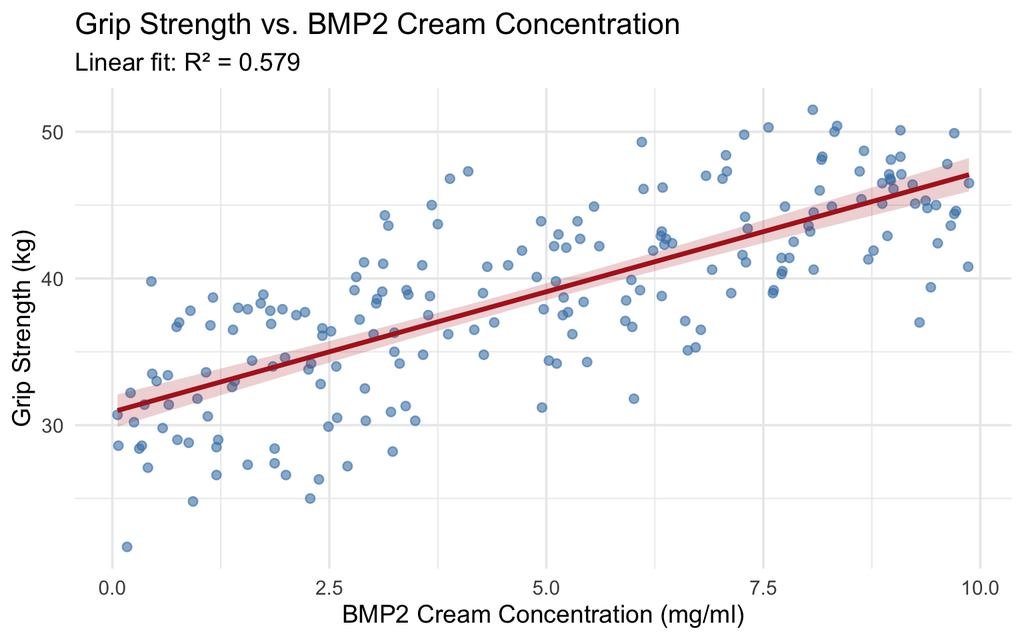

```r
ggplot(grip, aes(x = bmp2_cream_mg_ml, y = grip_strength_kg)) +
  geom_point(color = "steelblue", alpha = 0.6, size = 2) +
  geom_smooth(method = "lm", se = TRUE, color = "firebrick",
              fill = "firebrick", alpha = 0.2) +
  labs(
    x = "BMP2 Cream Concentration (mg/ml)",
    y = "Grip Strength (kg)",
    title = "Grip Strength vs. BMP2 Cream Concentration",
    subtitle = paste0("Linear fit: R² = ", round(summary(lm_bmp2)$r.squared, 3))
  ) +
  theme_minimal(base_size = 14)
```

- The scatterplot shows the relationship between BMP2 cream concentration and grip strength, with the OLS regression line and 95% confidence band overlaid.
- The confidence ribbon represents uncertainty in the estimated mean response – it is narrowest near $\bar{x}$ and widens at the extremes.
- A tight ribbon with a clear upward trend confirms a strong positive linear relationship, consistent with the high $R^2$.

# Exercise Hours

## Grip Strength ~ Exercise Hours

Now we test whether hours of exercise per week predict grip strength:

- Equation
- LaTeX
- Interpretation

$$\text{grip_strength}_i = \beta_0 + \beta_1 \cdot \text{exercise_hrs}_i + \epsilon_i$$

```
\text{grip_strength}_i = \beta_0 + \beta_1 \cdot \text{exercise_hrs}_i + \epsilon_i
```

- This model tests whether weekly exercise hours linearly predict grip strength.
- $\beta_1$ represents the expected change in grip strength for each additional hour of exercise per week.
- As we will see, this linear model may not be the best fit – the relationship could be nonlinear.
- Output
- Code
- Interpretation

```
Call:
lm(formula = grip_strength_kg ~ exercise_hrs_week, data = grip)

Residuals:
     Min       1Q   Median       3Q      Max
-17.0361  -4.3986   0.1145   4.8328  12.6600

Coefficients:
                   Estimate Std. Error t value Pr(>|t|)
(Intercept)       38.732172   0.897512  43.155   <2e-16 ***
exercise_hrs_week  0.009799   0.076992   0.127    0.899
---
Signif. codes:  0 '***' 0.001 '**' 0.01 '*' 0.05 '.' 0.1 ' ' 1

Residual standard error: 6.364 on 198 degrees of freedom
Multiple R-squared:  8.179e-05, Adjusted R-squared:  -0.004968
F-statistic: 0.0162 on 1 and 198 DF,  p-value: 0.8989
```

```r
lm_exercise <- lm(grip_strength_kg ~ exercise_hrs_week, data = grip)
summary(lm_exercise)
```

- The `summary()` output for the exercise model shows the estimated relationship between exercise hours and grip strength.
- Compare the $R^2$ value here to the BMP2 model – a much lower $R^2$ suggests exercise hours explain far less of the variability in grip strength.
- However, a poor linear fit does not mean there is no relationship – the relationship may be nonlinear.

## Interpreting the Model Output

- Output
- Code
- Interpretation

| term | estimate | std.error | statistic | p.value |
| --- | --- | --- | --- | --- |
| (Intercept) | 38.7322 | 0.8975 | 43.1551 | 0.0000 |
| exercise_hrs_week | 0.0098 | 0.0770 | 0.1273 | 0.8989 |

| r.squared | adj.r.squared | sigma | statistic | p.value | df | logLik | AIC | BIC | deviance | df.residual | nobs |
| --- | --- | --- | --- | --- | --- | --- | --- | --- | --- | --- | --- |
| 1e-04 | -0.005 | 6.364 | 0.0162 | 0.8989 | 1 | -652.915 | 1311.83 | 1321.725 | 8019.172 | 198 | 200 |

```r
tidy(lm_exercise) |> kable(digits = 4)
glance(lm_exercise) |> kable(digits = 4)
```

- Notice that the exercise model has a much lower $R^2$ than the BMP2 model.
- This suggests that exercise hours alone explain very little of the variation in grip strength.
- But we should check whether the relationship might be nonlinear before concluding.

## Visualizing Grip Strength ~ Exercise Hours

- Output
- Code
- Interpretation

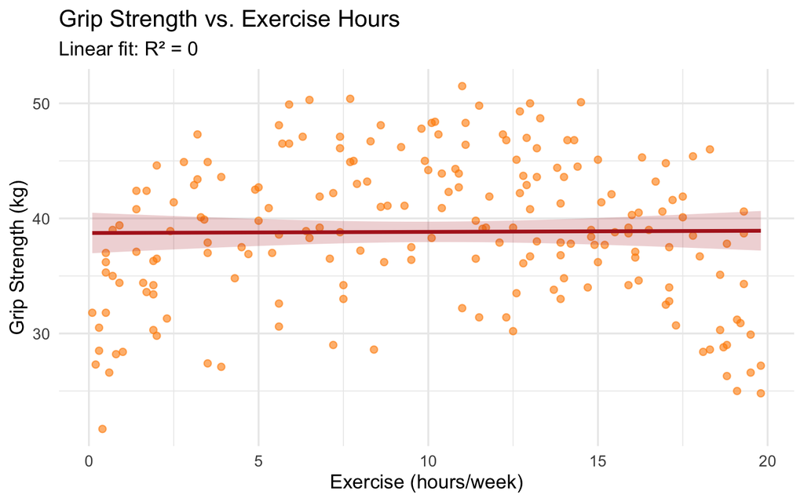

```r
ggplot(grip, aes(x = exercise_hrs_week, y = grip_strength_kg)) +
  geom_point(color = "darkorange", alpha = 0.6, size = 2) +
  geom_smooth(method = "lm", se = TRUE, color = "firebrick",
              fill = "firebrick", alpha = 0.2) +
  labs(
    x = "Exercise (hours/week)",
    y = "Grip Strength (kg)",
    title = "Grip Strength vs. Exercise Hours",
    subtitle = paste0("Linear fit: R² = ", round(summary(lm_exercise)$r.squared, 3))
  ) +
  theme_minimal(base_size = 14)
```

- The scatterplot with the linear fit shows a weak relationship between exercise hours and grip strength, reflected in the low $R^2$.
- The wide confidence ribbon indicates substantial uncertainty in the estimated mean response.
- Compare this visually to the BMP2 plot – the scatter is much more diffuse relative to the trend line.

## Comparing Both Fits Side by Side

- Output
- Code
- Interpretation
- Enhancement

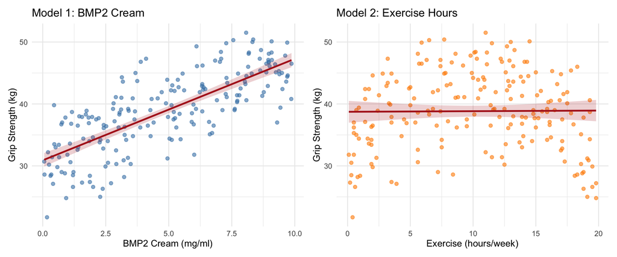

```r
library(patchwork)

p1 <- ggplot(grip, aes(x = bmp2_cream_mg_ml, y = grip_strength_kg)) +
  geom_point(color = "steelblue", alpha = 0.6, size = 2) +
  geom_smooth(method = "lm", se = TRUE, color = "firebrick", fill = "firebrick", alpha = 0.2) +
  labs(x = "BMP2 Cream (mg/ml)", y = "Grip Strength (kg)",
       title = "Model 1: BMP2 Cream") +
  theme_minimal(base_size = 13)

p2 <- ggplot(grip, aes(x = exercise_hrs_week, y = grip_strength_kg)) +
  geom_point(color = "darkorange", alpha = 0.6, size = 2) +
  geom_smooth(method = "lm", se = TRUE, color = "firebrick", fill = "firebrick", alpha = 0.2) +
  labs(x = "Exercise (hours/week)", y = "Grip Strength (kg)",
       title = "Model 2: Exercise Hours") +
  theme_minimal(base_size = 13)

p1 + p2  # patchwork combines plots side-by-side
```

- Placing both models side by side makes the contrast clear: BMP2 cream shows a strong, tight linear relationship while exercise hours shows a weak, diffuse one.
- The patchwork package makes it easy to compose multiple ggplot panels for comparison.
- This visual comparison is more informative than comparing $R^2$ values alone – you can see the difference in scatter and confidence band width.

```r
# Combine into a single faceted plot using pivot_longer
grip_long <- grip |>
  pivot_longer(cols = c(bmp2_cream_mg_ml, exercise_hrs_week),
               names_to = "predictor", values_to = "value")

ggplot(grip_long, aes(x = value, y = grip_strength_kg)) +
  geom_point(alpha = 0.5) +
  geom_smooth(method = "lm", se = TRUE) +
  facet_wrap(~ predictor, scales = "free_x") +
  theme_minimal()
```

- An alternative approach uses `pivot_longer()` and `facet_wrap()` to create a single faceted plot, which scales well when comparing many predictors.

# Other R Packages for Fitting Linear Models

## Using aov() for ANOVA-Style Output

- The `aov()` function fits the same underlying model as `lm()`, but presents the results in an analysis of variance (ANOVA) table format.
- This is useful when you want to focus on the partitioning of variance rather than individual coefficient estimates.
- Output
- Code
- Interpretation

```
                  Df Sum Sq Mean Sq F value Pr(>F)
bmp2_cream_mg_ml   1   4646    4646   272.7 <2e-16 ***
Residuals        198   3374      17
---
Signif. codes:  0 '***' 0.001 '**' 0.01 '*' 0.05 '.' 0.1 ' ' 1
```

```r
# aov() gives ANOVA table output for the same model
aov_bmp2 <- aov(grip_strength_kg ~ bmp2_cream_mg_ml, data = grip)
summary(aov_bmp2)
```

- The `aov()` output decomposes total variance into model (BMP2 cream) and residual components.
- The F-statistic tests whether the model explains significantly more variance than expected by chance.
- The `aov()` and `lm()` functions fit the same underlying model – they just present results differently (ANOVA table vs. coefficient table).
- The ANOVA table decomposes variance into the model sum of squares ($SS_{Model}$) and residual sum of squares ($SS_{Error}$).
- It also tests whether the model explains a significant proportion of variance via the F-statistic.

## Using anova() to Compare Models

The `anova()` function can also be applied to `lm` objects directly, and it is especially useful for comparing nested models:

- Output
- Code
- Interpretation

```
Analysis of Variance Table

Response: grip_strength_kg
                  Df Sum Sq Mean Sq F value    Pr(>F)
bmp2_cream_mg_ml   1 4646.3  4646.3   272.7 < 2.2e-16 ***
Residuals        198 3373.5    17.0
---
Signif. codes:  0 '***' 0.001 '**' 0.01 '*' 0.05 '.' 0.1 ' ' 1
```

```r
# ANOVA table from an lm object
anova(lm_bmp2)
```

- `anova()` applied to an `lm` object produces the same ANOVA decomposition as `aov()`, showing $SS_{Model}$, $SS_{Error}$, and the F-test.
- This function is especially useful for comparing nested models by passing two `lm` objects (e.g., `anova(model1, model2)`).
- The significant F-statistic confirms that BMP2 cream concentration explains a significant amount of variance in grip strength.

## Overview of R Packages for Linear Models

R provides a rich ecosystem of packages for fitting models of increasing complexity:

| Package / Function | Use Case | Key Feature |
| --- | --- | --- |
| `lm()` | Simple/multiple linear regression | Coefficient estimates, $R^2$, F-test |
| `aov()` | ANOVA-style linear models | Variance partitioning, F-table |
| `glm()` | Generalized linear models | Non-normal response (logistic, Poisson) |
| `lme4::lmer()` | Linear mixed-effects models | Random effects for nested/grouped data |
| `nlme::lme()` | Linear mixed-effects models | Flexible correlation structures |
| `MASS::rlm()` | Robust linear regression | Resistant to outliers |
| `mgcv::gam()` | Generalized additive models | Smooth nonlinear relationships |

## Fitting with glm()

The `glm()` function fits generalized linear models. With the default `family = gaussian`, it is equivalent to `lm()`:

- Output
- Code
- Interpretation

```
Call:
glm(formula = grip_strength_kg ~ bmp2_cream_mg_ml, family = gaussian,
    data = grip)

Coefficients:
                 Estimate Std. Error t value Pr(>|t|)
(Intercept)      30.89979    0.56202   54.98   <2e-16 ***
bmp2_cream_mg_ml  1.63861    0.09923   16.51   <2e-16 ***
---
Signif. codes:  0 '***' 0.001 '**' 0.01 '*' 0.05 '.' 0.1 ' ' 1

(Dispersion parameter for gaussian family taken to be 17.03807)

    Null deviance: 8019.8  on 199  degrees of freedom
Residual deviance: 3373.5  on 198  degrees of freedom
AIC: 1138.7

Number of Fisher Scoring iterations: 2
```

```r
# glm() with family = gaussian is equivalent to lm()
glm_bmp2 <- glm(grip_strength_kg ~ bmp2_cream_mg_ml, data = grip, family = gaussian)
summary(glm_bmp2)
```

- With `family = gaussian`, `glm()` produces identical results to `lm()` – the same coefficient estimates and standard errors.
- The advantage of `glm()` is its flexibility: changing the `family` argument allows fitting logistic regression (`binomial`), Poisson regression (`poisson`), and other generalized linear models.
- Note that `glm()` reports deviance and AIC rather than $R^2$ and adjusted $R^2$.

## Fitting with glm()

- The advantage of `glm()` is that it generalizes to non-normal responses by changing the `family` argument
- `binomial` for logistic regression
- `poisson` for count data
- We will use this later in the course.

## How to report linear model statistics

- Say what you found, and then put the statistics in parentheses.
- Support the finding with the statistics, not the other way around.
- Remember to include magnitude and direction of the finding.
- Also, reference the figure that shows the relationship.

**Note**

We found that topical application of a cream containing the signaling molecule bone morphogenetic protein 2 (bmp-2) significantly increased the grip strength of patients in a clinical trial ($F_{1,198} = 272.7; p<2e^{-16}; R^2 = 0.58$), Specifically, an increase of 1mg/ml of bmp-2 was correlated with an increase of 1.64 kg of grip strength (Fig. 1)

# Residual Analysis

## Why Residual Analysis?

- Fitting a linear model is only the first step.
- Before we trust the model’s coefficient estimates, p-values, and confidence intervals, we must verify that the **assumptions** underlying the model are reasonably met.
- If assumptions are violated, the standard errors and p-values may be unreliable, and our conclusions could be misleading.
- Residual analysis is the primary diagnostic tool for checking these assumptions.
- By examining patterns in the residuals ($e_i = y_i - \hat{y}_i$), we can detect violations that aren’t obvious from the raw data alone.

## Assumptions of Linear Regression

Linear regression makes four key assumptions, often remembered by the acronym **LINE**:

- **L — Linearity**: The relationship between $x$ and $y$ is linear. The expected value of $y$ is a straight-line function of $x$.
- **I — Independence**: The residuals are independent of each other. Knowing one residual gives no information about another. Violations often occur with time series or spatially structured data.
- **N — Normality**: The residuals follow a normal distribution at each value of $x$: $\epsilon_i \sim N(0, \sigma^2)$. This assumption is most important for small sample sizes; with large $n$, the Central Limit Theorem makes inference robust to moderate departures.
- **E — Equal variance (Homoscedasticity)**: The variance of the residuals is constant across all values of $x$: $\text{Var}(\epsilon_i) = \sigma^2$ for all $i$. When variance changes with $x$ (heteroscedasticity), standard errors become biased.

## Visualizing the Assumptions

The figure below illustrates what the conditional distributions of $y$ should look like at each value of $x$ under a well-specified linear model: each distribution is normal, centered on the regression line, and has equal spread.

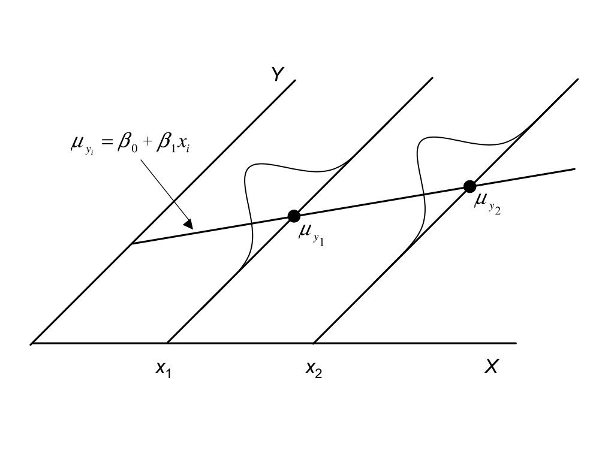

## Visualizing the Assumptions (SVG)

[figure not shown]

## Spotting Assumption Violations

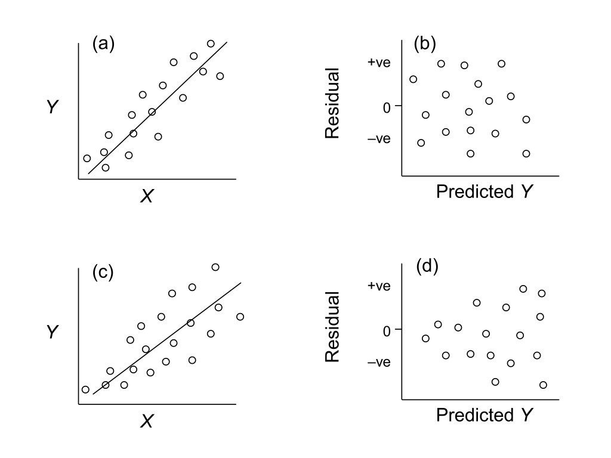

## Spotting Assumption Violations (SVG)

[figure not shown]

## DRAFT: Homoscedasticity vs Heteroscedasticity

- Output
- Code
- Interpretation

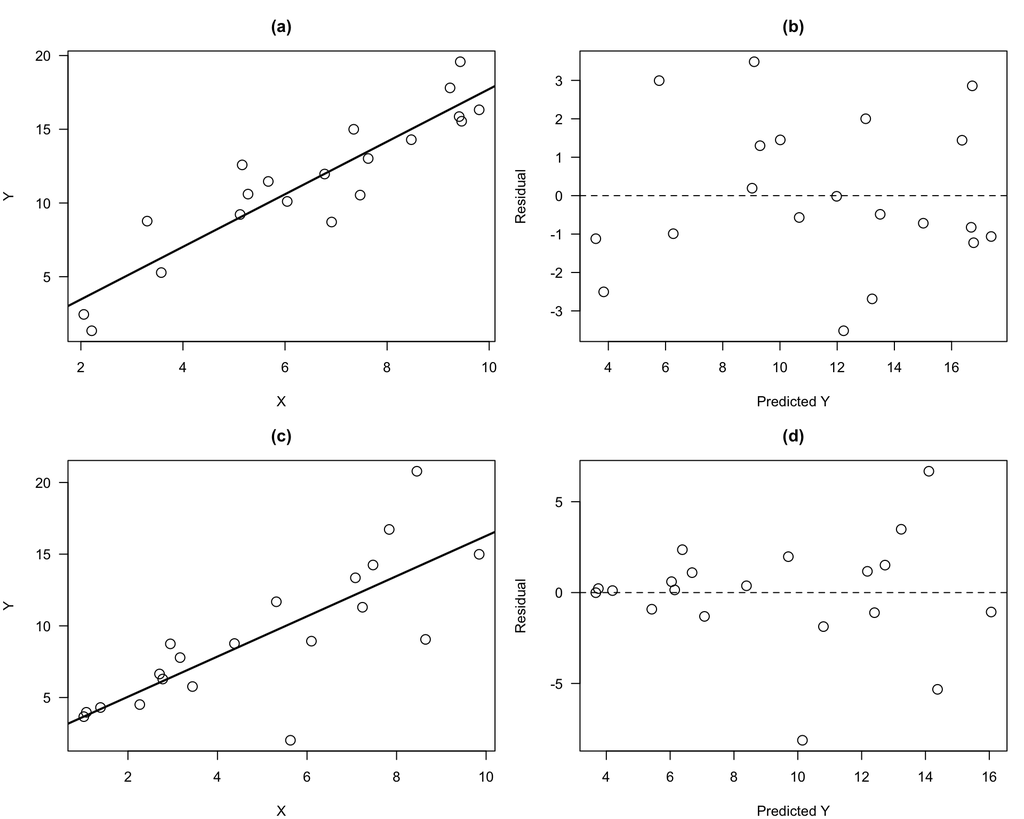

```r
par(mfrow = c(2, 2), mar = c(4, 4, 3, 1))

set.seed(42)
n <- 20
x_good <- runif(n, 1, 10)
y_good <- 2 + 1.5 * x_good + rnorm(n, 0, 1.5)
fit_good <- lm(y_good ~ x_good)

# (a) Good fit and (b) Good residuals
plot(x_good, y_good, pch = 1, cex = 1.5, xlab = "X", ylab = "Y", main = "(a)")
abline(fit_good, lwd = 2)
plot(fitted(fit_good), residuals(fit_good), pch = 1, cex = 1.5,
     xlab = "Predicted Y", ylab = "Residual", main = "(b)")
abline(h = 0, lty = 2)

# (c) Heteroscedastic fit and (d) its residuals
x_het <- runif(n, 1, 10)
y_het <- 2 + 1.5 * x_het + rnorm(n, 0, x_het * 0.5)
fit_het <- lm(y_het ~ x_het)
plot(x_het, y_het, pch = 1, cex = 1.5, xlab = "X", ylab = "Y", main = "(c)")
abline(fit_het, lwd = 2)
plot(fitted(fit_het), residuals(fit_het), pch = 1, cex = 1.5,
     xlab = "Predicted Y", ylab = "Residual", main = "(d)")
abline(h = 0, lty = 2)
```

- **(a-b)** show a well-behaved linear model: the scatterplot shows a clear linear trend, and the residual plot shows random scatter with constant variance (homoscedasticity).
- **(c-d)** show a heteroscedastic model: the spread of points increases with X. The residual plot reveals a **funnel shape**, indicating the equal-variance assumption is violated.
- When heteroscedasticity is present, standard errors and p-values from OLS may be unreliable. Remedies include log-transforming Y, using weighted least squares, or robust standard errors.

## Spotting Assumption Violations

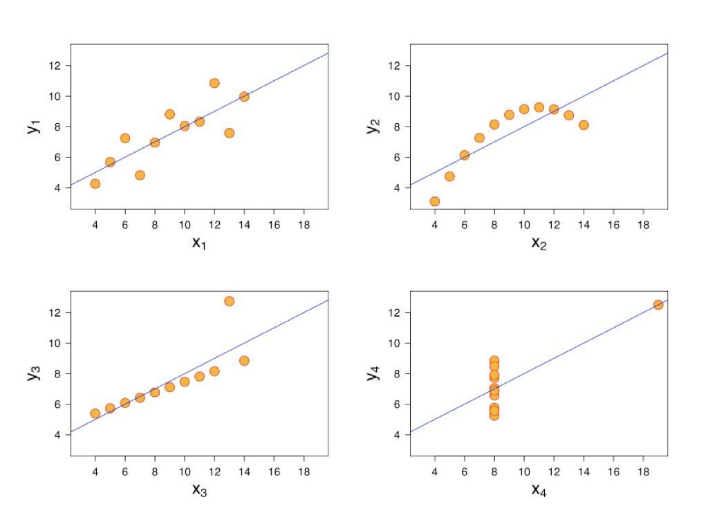

Source: Anscombe, F.J. (1973). “Graphs in Statistical Analysis.” *The American Statistician*, 27(1), 17-21.

## DRAFT: Anscombe’s Quartet

- Output
- Code
- Interpretation

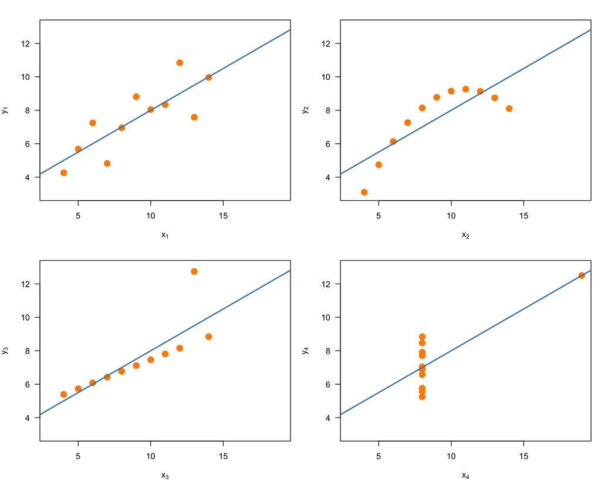

```r
library(datasets)
par(mfrow = c(2, 2), mar = c(4, 4, 2, 1))

for (i in 1:4) {
  xi <- anscombe[[paste0("x", i)]]
  yi <- anscombe[[paste0("y", i)]]
  plot(xi, yi, pch = 16, cex = 1.8, col = "darkorange",
       xlab = bquote(x[.(i)]), ylab = bquote(y[.(i)]),
       xlim = c(3, 19), ylim = c(3, 13), las = 1)
  abline(lm(yi ~ xi), col = "steelblue", lwd = 2)
}
```

- All four datasets have nearly identical summary statistics ($\bar{x}=9$, $\bar{y} \approx 7.5$, $r \approx 0.82$, same regression line) but very different patterns.
- **Dataset 1**: A well-behaved linear relationship. **Dataset 2**: A clear nonlinear (quadratic) pattern that a straight line cannot capture.
- **Dataset 3**: A perfect linear relationship with one outlier pulling the fit. **Dataset 4**: No relationship in X, but one extreme point creates an apparent correlation.
- This classic example demonstrates why **visualization is essential** – summary statistics alone can be deeply misleading.

All four datasets have nearly identical summary statistics ($\bar{x}=9$, $\bar{y} \approx 7.5$, $r \approx 0.82$, same regression line) but very different patterns.

## Spotting Assumption Violations

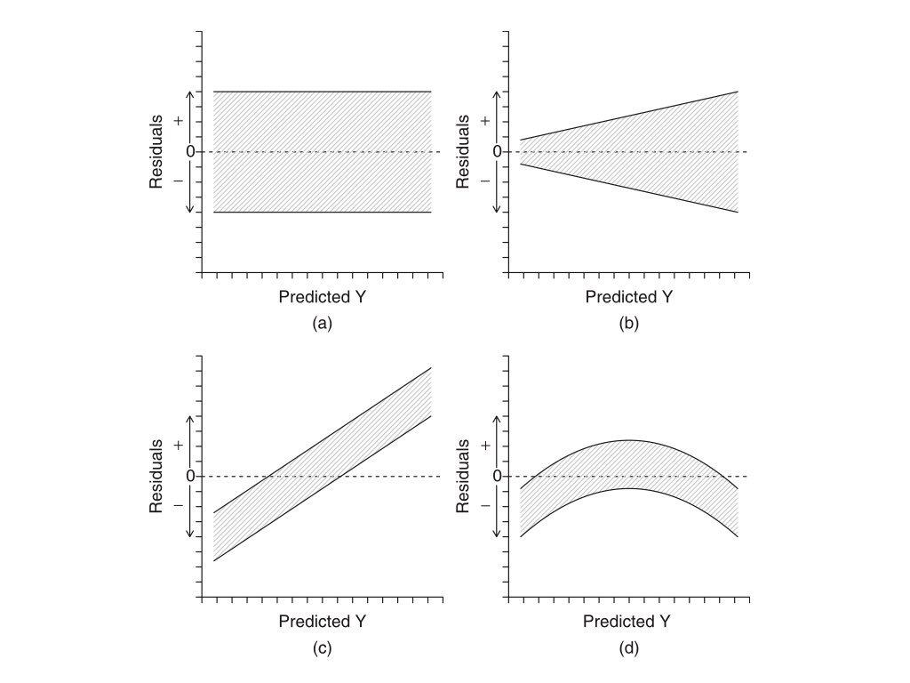

## Spotting Assumption Violations (SVG)

[figure not shown]

## DRAFT: Residual Patterns

- Output
- Code
- Interpretation

[figure not shown]

```r
par(mfrow = c(2, 2), mar = c(4, 4, 3, 1))

set.seed(1)
x <- 1:50

# (a) Homoscedastic - good
resid_a <- rnorm(50, 0, 1)
plot(x, resid_a, pch = 1, xlab = "Predicted Y", ylab = "Residuals",
     main = "(a) Homoscedastic", ylim = c(-4, 4), las = 1)
abline(h = 0, lty = 2)

# (b) Funnel (heteroscedastic)
resid_b <- rnorm(50, 0, x * 0.08)
plot(x, resid_b, pch = 1, xlab = "Predicted Y", ylab = "Residuals",
     main = "(b) Funnel (heteroscedastic)", ylim = c(-4, 4), las = 1)
abline(h = 0, lty = 2)

# (c) Linear trend
resid_c <- rnorm(50, 0, 0.5) + (x - 25) * 0.06
plot(x, resid_c, pch = 1, xlab = "Predicted Y", ylab = "Residuals",
     main = "(c) Linear trend", ylim = c(-4, 4), las = 1)
abline(h = 0, lty = 2)

# (d) Curvilinear
resid_d <- rnorm(50, 0, 0.5) + sin(x / 8) * 2
plot(x, resid_d, pch = 1, xlab = "Predicted Y", ylab = "Residuals",
     main = "(d) Curvilinear", ylim = c(-4, 4), las = 1)
abline(h = 0, lty = 2)
```

- **(a) Homoscedastic**: Ideal pattern – random scatter with constant spread around zero. No assumption violations.
- **(b) Funnel**: Variance increases with predicted values (heteroscedasticity). Consider log-transforming Y or using weighted least squares.
- **(c) Linear trend**: Residuals still have a systematic relationship with predicted values, suggesting a missing predictor or incorrect functional form.
- **(d) Curvilinear**: A U-shaped or sinusoidal pattern indicates the true relationship is nonlinear. Consider adding polynomial terms or using a different model.

## Common Residual Patterns and Causes

Understanding what different residual patterns mean helps you decide how to fix model problems:

- **Funnel shape** (variance increases with fitted values): Heteroscedasticity. Consider a variance-stabilizing transformation (e.g., log) or use weighted least squares.
- **Curved pattern** (U-shape or arch): The relationship is nonlinear. Consider adding polynomial terms (e.g., $x^2$) or using a different model.
- **Clusters or groups**: There may be a missing categorical variable or subgroup structure in the data (recall Simpson’s Paradox).
- **Systematic pattern over time/order**: Autocorrelation among residuals. Consider time-series models or including a time covariate.

## What Each Residual Plot Tells You

The standard `plot(lm_object)` in R produces four diagnostic plots. Each one targets a specific assumption:

| Plot | Name | What It Checks | What to Look For |
| --- | --- | --- | --- |
| 1 | Residuals vs. Fitted | Linearity & equal variance | No pattern; random scatter around 0 |
| 2 | Normal Q-Q | Normality of residuals | Points follow the diagonal line |
| 3 | Scale-Location | Homoscedasticity | Flat trend line; no fan shape |
| 4 | Residuals vs. Leverage | Influential observations | No points beyond Cook’s distance lines |

## Residual Diagnostic Plots

- Output
- Code
- Interpretation

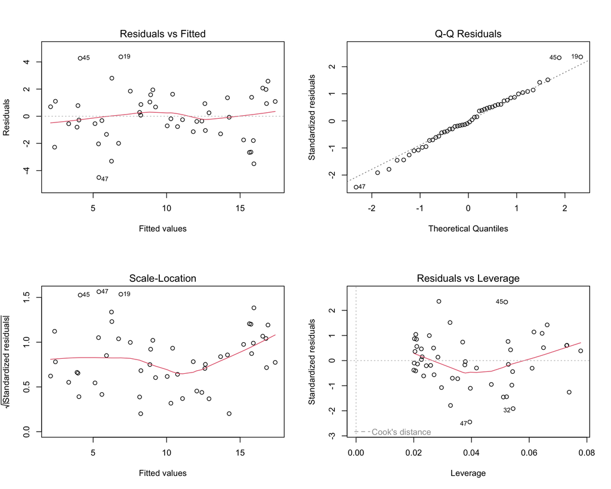

```r
par(mfrow = c(2, 2))
plot(my_lm)
```

- The four diagnostic plots check the LINE assumptions: Linearity, Independence, Normality, and Equal variance.
- **Residuals vs. Fitted**: Look for random scatter around zero (no pattern = good). **Q-Q Plot**: Points should follow the diagonal line (normality).
- **Scale-Location**: Should show a flat trend (constant variance). **Residuals vs. Leverage**: Identifies influential observations (high Cook’s distance).

## Using ggfortify for Diagnostics

- Output
- Code
- Interpretation
- Enhancement

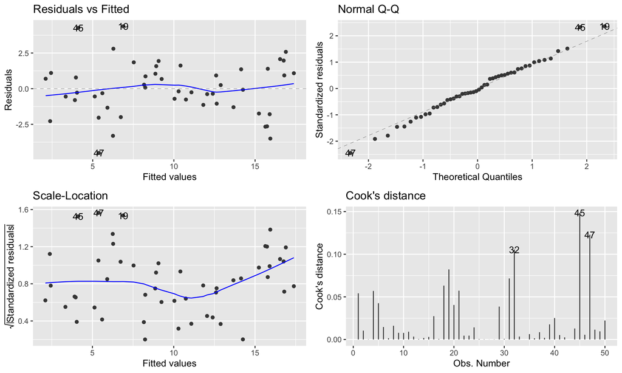

```r
library(ggfortify)
autoplot(my_lm, which = 1:4, ncol = 2)
```

```r
# Alternative: use performance package for comprehensive diagnostics
# install.packages("performance")
library(performance)
check_model(my_lm)
```

- The `performance::check_model()` function provides an even more comprehensive set of diagnostic plots in a single call, including posterior predictive checks and variance inflation factor plots.

## Outlier Leverage and Influence

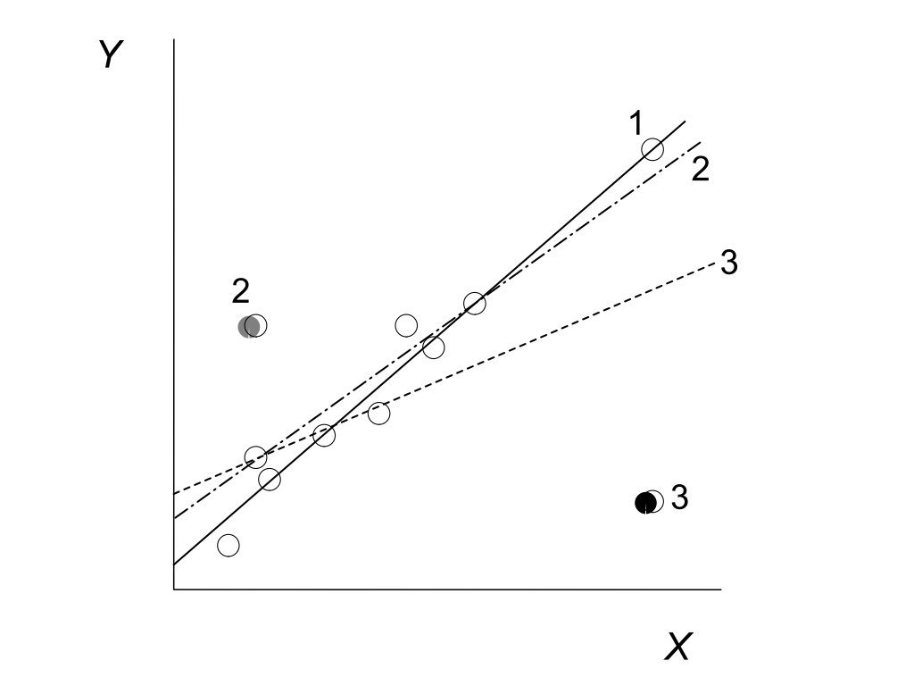

## Outlier Leverage and Influence (SVG)

[figure not shown]

## DRAFT: Outlier Leverage and Influence

- Output
- Code
- Interpretation

[figure not shown]

```r
set.seed(42)
x <- c(1, 2, 3, 4, 5, 6, 7, 8, 9, 10)
y <- c(0.5, 1, 1.8, 2.3, 3.5, 4, 4.2, 5, 5.5, 6.5)
x_all <- c(x, 3, 9)
y_all <- c(y, 5, 2)

plot(x_all, y_all, pch = c(rep(1, 10), 16, 16), cex = c(rep(1.5, 10), 2.5, 2.5),
     col = c(rep("black", 10), "gray50", "gray20"),
     xlab = "X", ylab = "Y", las = 1, xlim = c(0, 11), ylim = c(0, 8))

fit1 <- lm(y ~ x)
abline(fit1, lwd = 2, lty = 1)
fit2 <- lm(y_all[c(1:10, 11)] ~ x_all[c(1:10, 11)])
abline(fit2, lwd = 2, lty = 4)
fit3 <- lm(y_all[c(1:10, 12)] ~ x_all[c(1:10, 12)])
abline(fit3, lwd = 2, lty = 2)

legend("topleft",
       c("1: Original fit", "2: + Low leverage outlier", "3: + High leverage outlier"),
       lty = c(1, 4, 2), lwd = 2, cex = 0.9)
```

- Point **2** (gray, at x=3) has a large residual but low leverage (it is near the center of x-space). It barely changes the regression line because it has little pull.
- Point **3** (dark gray, at x=9) has high leverage AND a large residual – it is an **influential** point that noticeably tilts the regression line toward itself.
- This demonstrates why Cook’s distance (which combines leverage and residual size) is more informative than either metric alone.

## Outlier Leverage and Influence

- **Leverage**: How much of an outlier in x-space
- **Residual**: How much of an outlier in y-space
- **Cook’s D**: Overall influence on fitted model
- A point with high leverage doesn’t necessarily distort the model — only if it also has a large residual.
- Cook’s distance combines both: it measures how much all the fitted values would change if that single observation were removed.

**Warning**

Cook’s D ≥ 1 indicates highly influential observations, and a rough rule of thumb is 4/n. Investigate these points — they may be data entry errors, measurement problems, or genuinely unusual cases.

# Residual Plots for the Grip Strength Models

## BMP2 Model

- The residuals vs. fitted values plot is our primary tool for checking linearity and homoscedasticity.
- If the model is well-specified, we expect to see a random cloud of points centered around zero with no systematic pattern.
- Output
- Code
- Interpretation

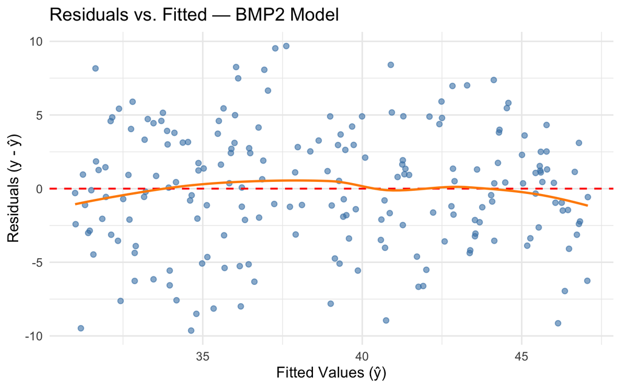

```r
bmp2_diag <- data.frame(
  fitted = fitted(lm_bmp2),
  residuals = residuals(lm_bmp2)
)

ggplot(bmp2_diag, aes(x = fitted, y = residuals)) +
  geom_point(color = "steelblue", alpha = 0.6, size = 2) +
  geom_hline(yintercept = 0, linetype = "dashed", color = "red", linewidth = 0.8) +
  geom_smooth(method = "loess", se = FALSE, color = "darkorange", linewidth = 1) +
  labs(
    x = "Fitted Values (ŷ)",
    y = "Residuals (y - ŷ)",
    title = "Residuals vs. Fitted — BMP2 Model"
  ) +
  theme_minimal(base_size = 14)
```

- The residuals vs. fitted plot for the BMP2 model should show a random cloud centered around zero with constant spread.
- The loess smoother (orange line) staying close to zero across all fitted values confirms the linearity assumption is met.
- Constant vertical spread of points indicates homoscedasticity – the equal variance assumption holds.
- The loess smoother (orange line) helps visualize any systematic trend.
- If it stays close to zero across the range of fitted values, linearity is satisfied.

## Exercise Model

- Output
- Code
- Interpretation

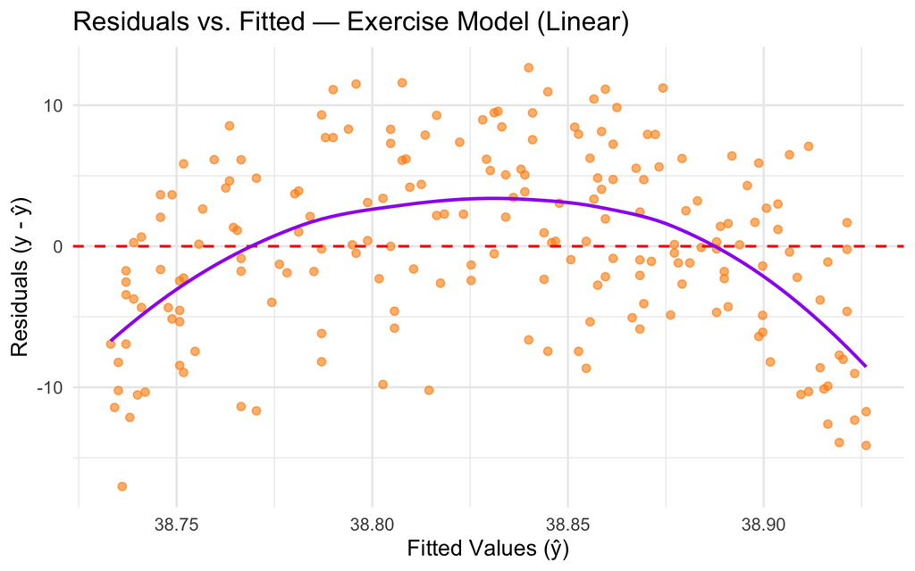

```r
exercise_diag <- data.frame(
  fitted = fitted(lm_exercise),
  residuals = residuals(lm_exercise)
)

ggplot(exercise_diag, aes(x = fitted, y = residuals)) +
  geom_point(color = "darkorange", alpha = 0.6, size = 2) +
  geom_hline(yintercept = 0, linetype = "dashed", color = "red", linewidth = 0.8) +
  geom_smooth(method = "loess", se = FALSE, color = "purple", linewidth = 1) +
  labs(
    x = "Fitted Values (ŷ)",
    y = "Residuals (y - ŷ)",
    title = "Residuals vs. Fitted — Exercise Model (Linear)"
  ) +
  theme_minimal(base_size = 14)
```

- The residuals vs. fitted plot for the exercise model may show a curved loess smoother, suggesting the linear model does not fully capture the relationship.
- A systematic curved pattern in the residuals indicates the true relationship between exercise and grip strength may be nonlinear.
- This diagnostic motivates exploring polynomial regression as an alternative to the simple linear model.

**Important**

Look carefully at the loess smoother — does it show curvature? If the residuals show a systematic curved pattern, this suggests a nonlinear relationship that a straight line cannot capture.

## Full Diagnostic Panel: BMP2 Model

- Output
- Code
- Interpretation
- Enhancement

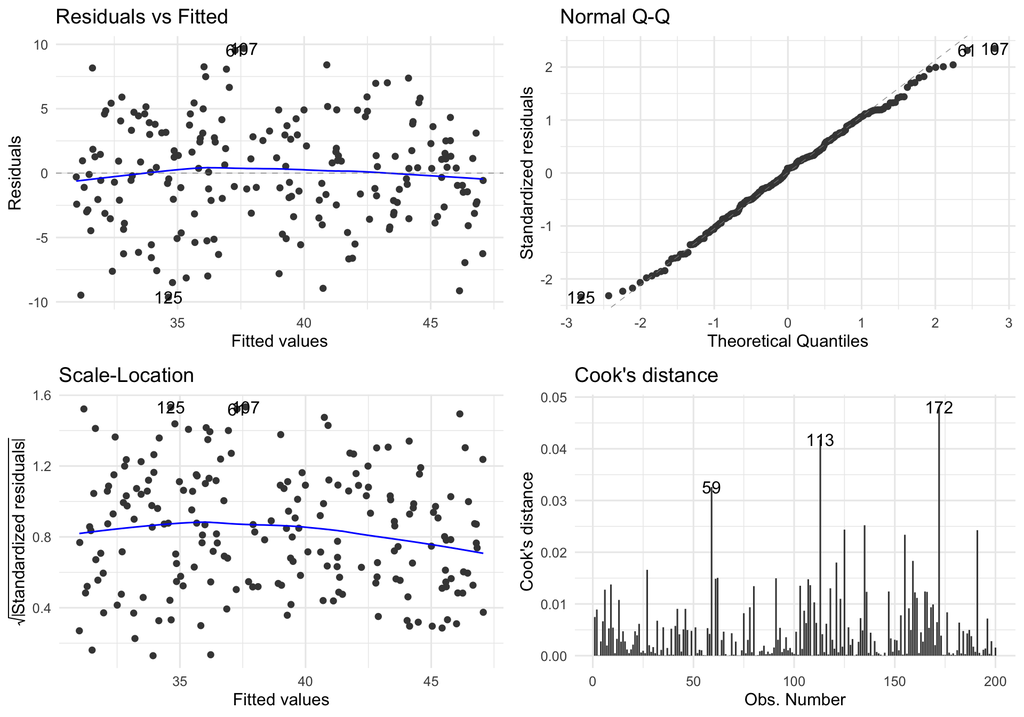

```r
autoplot(lm_bmp2, which = 1:4, ncol = 2) +
  theme_minimal(base_size = 12)
```

- The full diagnostic panel for the BMP2 model should confirm well-behaved residuals across all four diagnostic checks.
- Compare these plots to the exercise model diagnostics – the BMP2 model should show better adherence to LINE assumptions.
- If the Q-Q plot shows points close to the diagonal, normality of residuals is satisfied, supporting the validity of confidence intervals and p-values.

```r
# Alternative using ggfortify::autoplot with custom styling
autoplot(lm_bmp2, which = 1:4, ncol = 2,
         colour = "steelblue", smooth.colour = "firebrick") +
  theme_bw(base_size = 12)
```

- You can customize `autoplot()` colors and themes to match your presentation style.

## Full Diagnostic Panel: Exercise Model

- Output
- Code
- Interpretation

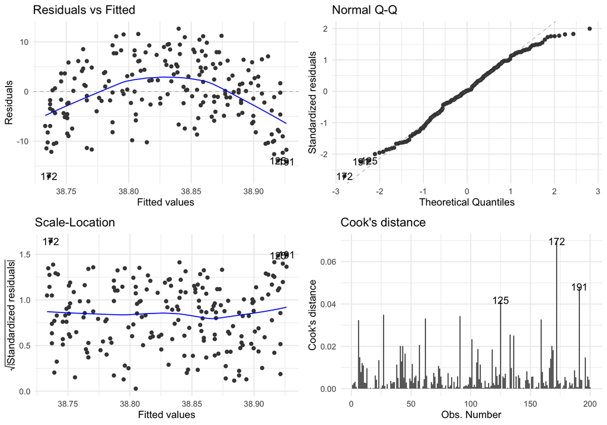

```r
autoplot(lm_exercise, which = 1:4, ncol = 2) +
  theme_minimal(base_size = 12)
```

- The diagnostic plots for the exercise model may show violations – particularly curvature in the Residuals vs. Fitted plot.
- Compare these diagnostics with the BMP2 model to see the contrast between a well-specified and a potentially misspecified model.
- Curvature in the residuals suggests that adding a polynomial term (e.g., quadratic) may improve the fit.